# Module 196

#### Hemi-module gene counts:

295 probesets in hemi-module A.  
217 probesets in hemi-module B.  
Note: While the mapping of probesets to genes is usually one-to-one, some genes are targeted by multiple probesets, some probesets target multiple genes, and some probesets do not target any genes (i.e., the region of the genome they match is no longer considered genic).

#### Contrast SVE:

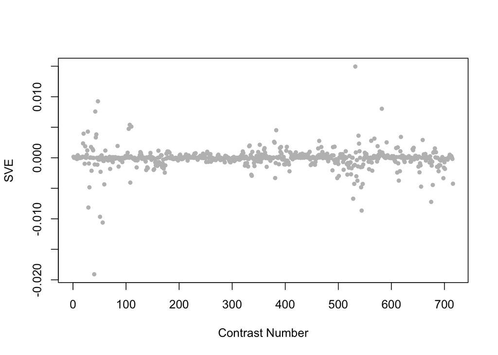

Positive SVE Contrasts:

|  | Contrast.Num | SVE | GEO.GSE | Cond.1 | Cond.2 | Mutation |
| --- | --- | --- | --- | --- | --- | --- |
| GSE2180.s4t9.vs.s3t9 | 532 | 0.01 | GSE2180 | pp143-1 | p143-2 | pal-1(RNAi) |
| GSE9665.s4t2.vs.s4t1 | 47 | 0.01 | GSE9665 | mex-3 hnd-1 186 A | mex-3 hnd-1 143 A |  |
| GSE2180.s2t2.vs.s2t1 | 582 | 0.01 | GSE2180 | ms23-1 | ms0-1 |  |
| GSE9665.s0t2.vs.s0t1 | 42 | 0.01 | GSE9665 | mex-3 186 A | mex-3 143 A |  |
| GSE54513.s4t1.vs.s1t1 | 107 | 0.01 | GSE54513 | spe-9 OMA-1 IP rep1 | fog-1 input rep1 |  |

Negative SVE Contrasts:

|  | Contrast.Num | SVE | GEO.GSE | Cond.1 | Cond.2 | Mutation |
| --- | --- | --- | --- | --- | --- | --- |
| GSE9665.s11t3.vs.s0t3 | 40 | -0.02 | GSE9665 | mex-3 unc-120 230 A | mex-3 230 A | unc-120 |
| GSE9665.s11t3.vs.s11t2 | 56 | -0.01 | GSE9665 | mex-3 unc-120 230 A | mex-3 unc-120 186 A |  |
| GSE9665.s8t4.vs.s8t1 | 51 | -0.01 | GSE9665 | mex-3 pal-1 101 A | mex-3 pal-1 143 A |  |
| GSE2180.s4t2.vs.s3t2 | 544 | -0.01 | GSE2180 | pp23-1 | p23-2 | pal-1(RNAi) |
| GSE9665.s8t2.vs.s0t2 | 29 | -0.01 | GSE9665 | mex-3 pal-1 186 A | mex-3 186 A | pal-1 |

$~$

#### Contrast SVE, Up-Regulated Genes Only:

Calculating SVE for up-regulated and down-regulated genes separately may be more informative in many cases than projecting the up- and down- gene sets together. This is due to the fact that the weight distribution of many modules is highly skewed, indicating that only one of the hemi-modules may be biologically meaningful (i.e., a set of genes are strongly correlated by only a few genes (or none) are strongly anti-correlated to that set.)

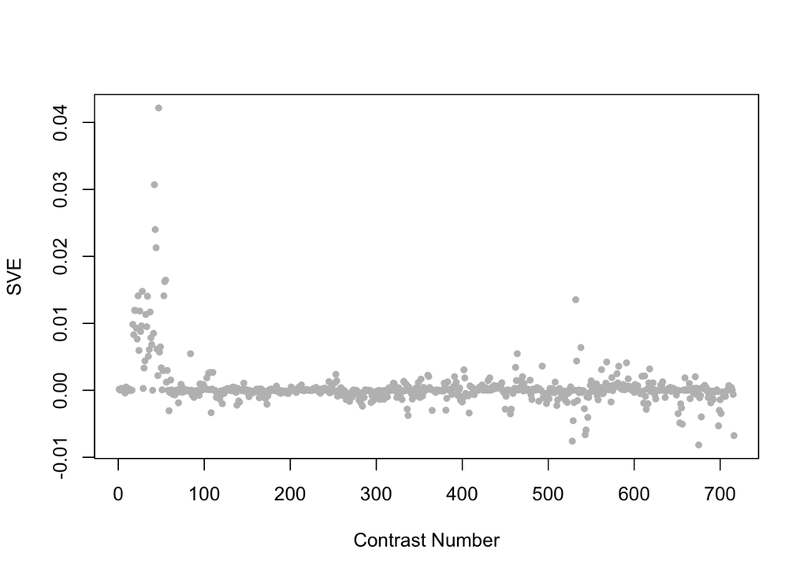

Positive SVE Contrasts:

|  | Contrast.Num | SVE | GEO.GSE | Cond.1 | Cond.2 | Mutation |
| --- | --- | --- | --- | --- | --- | --- |
| GSE9665.s4t2.vs.s4t1 | 47 | 0.04 | GSE9665 | mex-3 hnd-1 186 A | mex-3 hnd-1 143 A |  |
| GSE9665.s0t2.vs.s0t1 | 42 | 0.03 | GSE9665 | mex-3 186 A | mex-3 143 A |  |
| GSE9665.s0t3.vs.s0t1 | 43 | 0.02 | GSE9665 | mex-3 230 A | mex-3 143 A |  |
| GSE9665.s1t2.vs.s1t1 | 44 | 0.02 | GSE9665 | mex-3 elt-1 186 A | mex-3 elt-1 143 A |  |
| GSE9665.s10t2.vs.s10t1 | 55 | 0.02 | GSE9665 | mex-3 tbx-8,9 186 A | mex-3 tbx-8,9 143 A |  |

Negative SVE Contrasts:

|  | Contrast.Num | SVE | GEO.GSE | Cond.1 | Cond.2 | Mutation |
| --- | --- | --- | --- | --- | --- | --- |
| GSE13258.s4t1.vs.s0t1 | 675 | -0.01 | GSE13258 | alg-1 mutant, biological rep 1 | wild-type, biological rep 1 | alg-1 |
| GSE2180.s3t9.vs.s1t9 | 528 | -0.01 | GSE2180 | p143-2 | 143L | pie-1(zu154) |
| GSE10787B.s1t1.vs.s0t1 | 716 | -0.01 | GSE10787 | Microwave (de_Pomerai_10_E5_C.Elegans) | Sham (de_Pomerai_1_S1_C.Elegans) |  |
| GSE2180.s4t2.vs.s2t2 | 543 | -0.01 | GSE2180 | pp23-1 | ms23-1 |  |
| GSE2180.s4t2.vs.s3t2 | 544 | -0.01 | GSE2180 | pp23-1 | p23-2 | pal-1(RNAi) |

$~$

#### Contrast SVE, Down-Regulated Genes Only:

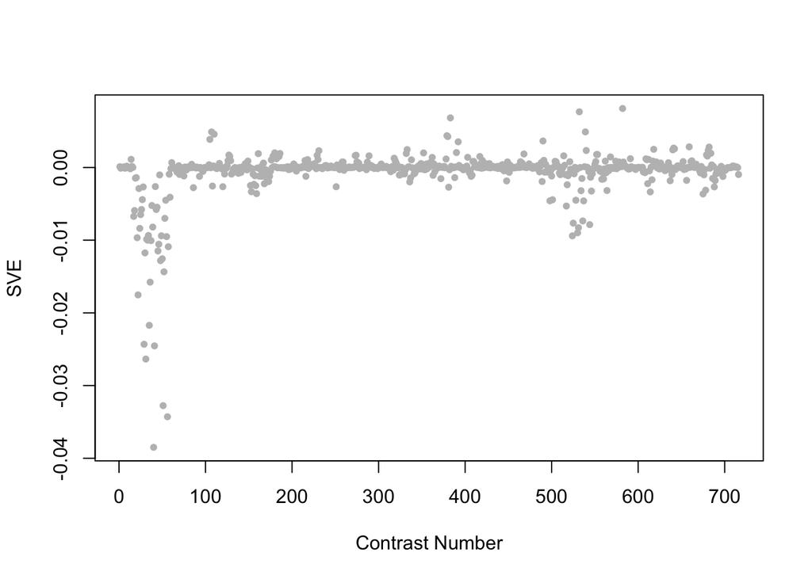

Positive SVE Contrasts:

|  | Contrast.Num | SVE | GEO.GSE | Cond.1 | Cond.2 | Mutation |
| --- | --- | --- | --- | --- | --- | --- |
| GSE2180.s2t2.vs.s2t1 | 582 | 0.01 | GSE2180 | ms23-1 | ms0-1 |  |
| GSE2180.s4t9.vs.s3t9 | 532 | 0.01 | GSE2180 | pp143-1 | p143-2 | pal-1(RNAi) |
| GSE34113.s1t1.vs.s0t1 | 383 | 0.01 | GSE34113 | tdp-1(ok803) | wild-type 1 | tdp-1 |
| GSE2180.s2t2.vs.s1t2 | 539 | 0.00 | GSE2180 | ms23-1 | 23-1 | mex-3(zu155);skn-1(RNAi) |
| GSE54513.s4t1.vs.s1t1 | 107 | 0.00 | GSE54513 | spe-9 OMA-1 IP rep1 | fog-1 input rep1 |  |

Negative SVE Contrasts:

|  | Contrast.Num | SVE | GEO.GSE | Cond.1 | Cond.2 | Mutation |
| --- | --- | --- | --- | --- | --- | --- |
| GSE9665.s11t3.vs.s0t3 | 40 | -0.04 | GSE9665 | mex-3 unc-120 230 A | mex-3 230 A | unc-120 |
| GSE9665.s11t3.vs.s11t2 | 56 | -0.03 | GSE9665 | mex-3 unc-120 230 A | mex-3 unc-120 186 A |  |
| GSE9665.s8t4.vs.s8t1 | 51 | -0.03 | GSE9665 | mex-3 pal-1 101 A | mex-3 pal-1 143 A |  |
| GSE9665.s10t2.vs.s0t2 | 31 | -0.03 | GSE9665 | mex-3 tbx-8,9 186 A | mex-3 186 A | tbx-8,9 |
| GSE9665.s12t3.vs.s0t3 | 41 | -0.02 | GSE9665 | mex-3 vab-7 230 A | mex-3 230 A | vab-7 |

$~$

$~$

#### GO Term Enrichment:

This analysis tests each hemi-module for enrichment of specific GO terms. Only gene-level annotations (e.g., as would be found on the gene’s page in Wormbase) are tested - the hierarchical structure of the GO ontology is not taken into account.

*Note: At least the top two most enriched terms from each GO domain (BP/MF/CC) are shown, even when not statistically significant.*

##### Enriched GO terms: Hemi-module A

| ID | GO.Term | GO Domain | Raw p-value | Adj p-value |
| --- | --- | --- | --- | --- |
| [GO_0000028](http://amigo.geneontology.org/amigo/term/GO:0000028) | ribosomal small subunit assembly | BP | 5.06e-05 | 7.11e-02 |
| [GO_0002181](http://amigo.geneontology.org/amigo/term/GO:0002181) | cytoplasmic translation | BP | 5.36e-05 | 7.11e-02 |
| [GO_0006120](http://amigo.geneontology.org/amigo/term/GO:0006120) | mitochondrial electron transport, NADH to ubiquinone | BP | 6.67e-05 | 7.11e-02 |
| [GO_0007186](http://amigo.geneontology.org/amigo/term/GO:0007186) | G protein-coupled receptor signaling pathway | BP | 7.81e-05 | 7.11e-02 |
| [GO_0003735](http://amigo.geneontology.org/amigo/term/GO:0003735) | structural constituent of ribosome | MF | 5.14e-06 | 1.05e-02 |
| [GO_0003723](http://amigo.geneontology.org/amigo/term/GO:0003723) | RNA binding | MF | 1.54e-04 | 1.57e-01 |
| [GO_0016021](http://amigo.geneontology.org/amigo/term/GO:0016021) | integral component of membrane | CC | 1.99e-11 | 1.85e-08 |
| [GO_0016020](http://amigo.geneontology.org/amigo/term/GO:0016020) | membrane | CC | 7.26e-07 | 3.37e-04 |
| [GO_0005840](http://amigo.geneontology.org/amigo/term/GO:0005840) | ribosome | CC | 8.85e-06 | 2.74e-03 |
| [GO_0005737](http://amigo.geneontology.org/amigo/term/GO:0005737) | cytoplasm | CC | 1.73e-05 | 4.00e-03 |
| [GO_0005634](http://amigo.geneontology.org/amigo/term/GO:0005634) | nucleus | CC | 6.21e-05 | 1.15e-02 |
| [GO_0008023](http://amigo.geneontology.org/amigo/term/GO:0008023) | transcription elongation factor complex | CC | 1.21e-04 | 1.86e-02 |
| [GO_0022625](http://amigo.geneontology.org/amigo/term/GO:0022625) | cytosolic large ribosomal subunit | CC | 1.48e-04 | 1.97e-02 |
| [GO_0000786](http://amigo.geneontology.org/amigo/term/GO:0000786) | nucleosome | CC | 2.40e-04 | 2.78e-02 |
| [GO_0005747](http://amigo.geneontology.org/amigo/term/GO:0005747) | mitochondrial respiratory chain complex I | CC | 3.25e-04 | 3.05e-02 |
| [GO_0071944](http://amigo.geneontology.org/amigo/term/GO:0071944) | cell periphery | CC | 3.28e-04 | 3.05e-02 |
| [GO_0005887](http://amigo.geneontology.org/amigo/term/GO:0005887) | integral component of plasma membrane | CC | 6.01e-04 | 5.00e-02 |
| [GO_0070469](http://amigo.geneontology.org/amigo/term/GO:0070469) | respiratory chain | CC | 6.46e-04 | 5.00e-02 |

##### Enriched GO terms: Hemi-module B

| ID | GO.Term | GO Domain | Raw p-value | Adj p-value |
| --- | --- | --- | --- | --- |
| [GO_0006412](http://amigo.geneontology.org/amigo/term/GO:0006412) | translation | BP | 1.36e-12 | 4.96e-09 |
| [GO_0006465](http://amigo.geneontology.org/amigo/term/GO:0006465) | signal peptide processing | BP | 1.67e-06 | 3.05e-03 |
| [GO_0015031](http://amigo.geneontology.org/amigo/term/GO:0015031) | protein transport | BP | 4.26e-06 | 5.18e-03 |
| [GO_0002181](http://amigo.geneontology.org/amigo/term/GO:0002181) | cytoplasmic translation | BP | 1.97e-05 | 1.79e-02 |
| [GO_0042274](http://amigo.geneontology.org/amigo/term/GO:0042274) | ribosomal small subunit biogenesis | BP | 6.48e-05 | 4.72e-02 |
| [GO_0006457](http://amigo.geneontology.org/amigo/term/GO:0006457) | protein folding | BP | 1.51e-04 | 9.19e-02 |
| [GO_0003735](http://amigo.geneontology.org/amigo/term/GO:0003735) | structural constituent of ribosome | MF | 7.88e-13 | 1.61e-09 |
| [GO_0015078](http://amigo.geneontology.org/amigo/term/GO:0015078) | proton transmembrane transporter activity | MF | 1.29e-04 | 1.31e-01 |
| [GO_0005840](http://amigo.geneontology.org/amigo/term/GO:0005840) | ribosome | CC | 1.71e-13 | 1.58e-10 |
| [GO_0016021](http://amigo.geneontology.org/amigo/term/GO:0016021) | integral component of membrane | CC | 2.02e-11 | 9.39e-09 |
| [GO_0016020](http://amigo.geneontology.org/amigo/term/GO:0016020) | membrane | CC | 4.77e-09 | 1.48e-06 |
| [GO_0022625](http://amigo.geneontology.org/amigo/term/GO:0022625) | cytosolic large ribosomal subunit | CC | 2.51e-07 | 5.82e-05 |
| [GO_0005634](http://amigo.geneontology.org/amigo/term/GO:0005634) | nucleus | CC | 1.19e-05 | 2.05e-03 |
| [GO_0005787](http://amigo.geneontology.org/amigo/term/GO:0005787) | signal peptidase complex | CC | 1.32e-05 | 2.05e-03 |
| [GO_0005789](http://amigo.geneontology.org/amigo/term/GO:0005789) | endoplasmic reticulum membrane | CC | 3.10e-05 | 4.12e-03 |
| [GO_0005685](http://amigo.geneontology.org/amigo/term/GO:0005685) | U1 snRNP | CC | 1.01e-04 | 1.09e-02 |
| [GO_0022627](http://amigo.geneontology.org/amigo/term/GO:0022627) | cytosolic small ribosomal subunit | CC | 1.06e-04 | 1.09e-02 |
| [GO_0005737](http://amigo.geneontology.org/amigo/term/GO:0005737) | cytoplasm | CC | 1.65e-04 | 1.53e-02 |
| [GO_0005783](http://amigo.geneontology.org/amigo/term/GO:0005783) | endoplasmic reticulum | CC | 3.62e-04 | 3.06e-02 |
| [GO_0033177](http://amigo.geneontology.org/amigo/term/GO:0033177) | proton-transporting two-sector ATPase complex, proton-transporting domain | CC | 6.69e-04 | 4.43e-02 |
| [GO_0071564](http://amigo.geneontology.org/amigo/term/GO:0071564) | npBAF complex | CC | 6.69e-04 | 4.43e-02 |
| [GO_0071565](http://amigo.geneontology.org/amigo/term/GO:0071565) | nBAF complex | CC | 6.69e-04 | 4.43e-02 |
| [GO_0005743](http://amigo.geneontology.org/amigo/term/GO:0005743) | mitochondrial inner membrane | CC | 8.13e-04 | 5.03e-02 |
| [GO_0005739](http://amigo.geneontology.org/amigo/term/GO:0005739) | mitochondrion | CC | 8.77e-04 | 5.09e-02 |
| [GO_0071004](http://amigo.geneontology.org/amigo/term/GO:0071004) | U2-type prespliceosome | CC | 1.08e-03 | 5.56e-02 |
| [GO_0005730](http://amigo.geneontology.org/amigo/term/GO:0005730) | nucleolus | CC | 1.08e-03 | 5.56e-02 |
| [GO_0005623](http://amigo.geneontology.org/amigo/term/GO:0005623) | cell | CC | 1.23e-03 | 6.01e-02 |
| [GO_0005753](http://amigo.geneontology.org/amigo/term/GO:0005753) | mitochondrial proton-transporting ATP synthase complex | CC | 1.32e-03 | 6.14e-02 |
| [GO_0005829](http://amigo.geneontology.org/amigo/term/GO:0005829) | cytosol | CC | 1.62e-03 | 7.14e-02 |
| [GO_0071013](http://amigo.geneontology.org/amigo/term/GO:0071013) | catalytic step 2 spliceosome | CC | 2.00e-03 | 8.45e-02 |
| [GO_0042788](http://amigo.geneontology.org/amigo/term/GO:0042788) | polysomal ribosome | CC | 2.18e-03 | 8.81e-02 |

$~$

$~$

#### Tissue Enrichment:

This analysis tests each hemi-module for enrichment of genes associated with anatomy terms. Negative enrichment scores indicate fewer hemi-module genes than expected by random chance were associated with the anatomy term in question.

##### Enriched tissues: Hemi-module A

| ID | Anatomy.Term | Definition | Raw p-value | Adj p-value |
| --- | --- | --- | --- | --- |
| [WBbt_0005813](https://wormbase.org/species/all/anatomy_term/WBbt:0005813) | body wall musculature | Longitudinal bands of muscle cells surrounding animal body, with one band running in each quadrant of the body, regulated contraction and relaxation of these muscles cause locomotion. | 1.81e-05 | 4.40e-02 |
| [WBbt_0003681](https://wormbase.org/species/all/anatomy_term/WBbt:0003681) | pharynx | the feeding organ, a neuro-muscular pump in the head of the animal, used to ingest food, bacteria suspended in liquid, filter them out, grind them up and transport posteriorly into the instestine. | 7.11e-05 | 8.65e-02 |

##### Enriched tissues: Hemi-module B

| ID | Anatomy.Term | Definition | Raw p-value | Adj p-value |
| --- | --- | --- | --- | --- |
| [WBbt_0005812](https://wormbase.org/species/all/anatomy_term/WBbt:0005812) | excretory cell | H-shaped cell associated with the excretory system, largest cell in C. elegans. | 1.73e-06 | 4.21e-03 |
| [WBbt_0004017](https://wormbase.org/species/all/anatomy_term/WBbt:0004017) | Cell | a cellular object that consists of subcellular components, expresses genes or functions. | 2.35e-05 | 2.49e-02 |
| [WBbt_0003681](https://wormbase.org/species/all/anatomy_term/WBbt:0003681) | pharynx | the feeding organ, a neuro-muscular pump in the head of the animal, used to ingest food, bacteria suspended in liquid, filter them out, grind them up and transport posteriorly into the instestine. | 3.07e-05 | 2.49e-02 |

$~$

$~$

#### HOMER promoter motif enrichment:

This analysis tests each hemi-module for enrichment of 108 known *C. elegans* transcription factor binding site motifs (see [108 CE motifs](https://katiepod.github.io//all.worm.motifs.html)) using the HOMER (Hypergeometric Optimization of Motif EnRichment) software (see [PMID:20513432](https://pubmed.ncbi.nlm.nih.gov/20513432)). HOMER was run using default parameters on sequences 1 kb upstream of the transcription start site.

##### Motif enrichment: Hemi-module A

Total target sequences = 248  
Total background sequences = 38655  
* - possible false positive

Rank

Motif

P-value

log P-pvalue

% of Targets

% of Background

STD(Bg STD)

Best Match/Details

Motif File

1 *

[figure not shown]

1e-10

-2.494e+01

18.55%

6.04%

267.0bp (327.9bp)

ceh-48/MA0921.1/Jaspar(0.535)  
[More Information](https://katiepod.github.io/HomerResults/m196_a_hemi_genes.txt.out.1kb/homerResults/motif1.info.html) | [Similar Motifs Found](https://katiepod.github.io/HomerResults/m196_a_hemi_genes.txt.out.1kb/homerResults/motif1.similar.html)

[motif file (matrix)](https://katiepod.github.io/HomerResults/m196_a_hemi_genes.txt.out.1kb/homerResults/motif1.motif)

2 *

[figure not shown]

1e-10

-2.461e+01

14.92%

4.11%

286.8bp (352.5bp)

eor-1/MA0543.1/Jaspar(0.592)  
[More Information](https://katiepod.github.io/HomerResults/m196_a_hemi_genes.txt.out.1kb/homerResults/motif2.info.html) | [Similar Motifs Found](https://katiepod.github.io/HomerResults/m196_a_hemi_genes.txt.out.1kb/homerResults/motif2.similar.html)

[motif file (matrix)](https://katiepod.github.io/HomerResults/m196_a_hemi_genes.txt.out.1kb/homerResults/motif2.motif)

3 *

[figure not shown]

1e-10

-2.400e+01

10.89%

2.27%

283.7bp (351.3bp)

pal-1/MA0924.1/Jaspar(0.627)  
[More Information](https://katiepod.github.io/HomerResults/m196_a_hemi_genes.txt.out.1kb/homerResults/motif3.info.html) | [Similar Motifs Found](https://katiepod.github.io/HomerResults/m196_a_hemi_genes.txt.out.1kb/homerResults/motif3.similar.html)

[motif file (matrix)](https://katiepod.github.io/HomerResults/m196_a_hemi_genes.txt.out.1kb/homerResults/motif3.motif)

4 *

[figure not shown]

1e-10

-2.378e+01

22.98%

9.01%

274.0bp (356.9bp)

PL0018.1_hlh-25/Jaspar(0.698)  
[More Information](https://katiepod.github.io/HomerResults/m196_a_hemi_genes.txt.out.1kb/homerResults/motif4.info.html) | [Similar Motifs Found](https://katiepod.github.io/HomerResults/m196_a_hemi_genes.txt.out.1kb/homerResults/motif4.similar.html)

[motif file (matrix)](https://katiepod.github.io/HomerResults/m196_a_hemi_genes.txt.out.1kb/homerResults/motif4.motif)

5 *

[figure not shown]

1e-9

-2.271e+01

27.02%

12.01%

287.6bp (328.4bp)

blmp-1/MA0537.1/Jaspar(0.587)  
[More Information](https://katiepod.github.io/HomerResults/m196_a_hemi_genes.txt.out.1kb/homerResults/motif5.info.html) | [Similar Motifs Found](https://katiepod.github.io/HomerResults/m196_a_hemi_genes.txt.out.1kb/homerResults/motif5.similar.html)

[motif file (matrix)](https://katiepod.github.io/HomerResults/m196_a_hemi_genes.txt.out.1kb/homerResults/motif5.motif)

6 *

[figure not shown]

1e-9

-2.231e+01

4.44%

0.27%

229.1bp (274.6bp)

mab-5/MA1442.1/Jaspar(0.648)  
[More Information](https://katiepod.github.io/HomerResults/m196_a_hemi_genes.txt.out.1kb/homerResults/motif6.info.html) | [Similar Motifs Found](https://katiepod.github.io/HomerResults/m196_a_hemi_genes.txt.out.1kb/homerResults/motif6.similar.html)

[motif file (matrix)](https://katiepod.github.io/HomerResults/m196_a_hemi_genes.txt.out.1kb/homerResults/motif6.motif)

7 *

[figure not shown]

1e-9

-2.186e+01

5.24%

0.46%

334.4bp (292.6bp)

skn-1/MA0547.1/Jaspar(0.601)  
[More Information](https://katiepod.github.io/HomerResults/m196_a_hemi_genes.txt.out.1kb/homerResults/motif7.info.html) | [Similar Motifs Found](https://katiepod.github.io/HomerResults/m196_a_hemi_genes.txt.out.1kb/homerResults/motif7.similar.html)

[motif file (matrix)](https://katiepod.github.io/HomerResults/m196_a_hemi_genes.txt.out.1kb/homerResults/motif7.motif)

8 *

[figure not shown]

1e-9

-2.176e+01

3.23%

0.09%

254.4bp (367.7bp)

PL0014.1_mxl-1::mdl-1/Jaspar(0.655)  
[More Information](https://katiepod.github.io/HomerResults/m196_a_hemi_genes.txt.out.1kb/homerResults/motif8.info.html) | [Similar Motifs Found](https://katiepod.github.io/HomerResults/m196_a_hemi_genes.txt.out.1kb/homerResults/motif8.similar.html)

[motif file (matrix)](https://katiepod.github.io/HomerResults/m196_a_hemi_genes.txt.out.1kb/homerResults/motif8.motif)

9 *

[figure not shown]

1e-9

-2.133e+01

2.82%

0.06%

312.7bp (369.4bp)

EFL-1(E2F)/cElegans-L1-EFL1-ChIP-Seq(modEncode)/Homer(0.563)  
[More Information](https://katiepod.github.io/HomerResults/m196_a_hemi_genes.txt.out.1kb/homerResults/motif9.info.html) | [Similar Motifs Found](https://katiepod.github.io/HomerResults/m196_a_hemi_genes.txt.out.1kb/homerResults/motif9.similar.html)

[motif file (matrix)](https://katiepod.github.io/HomerResults/m196_a_hemi_genes.txt.out.1kb/homerResults/motif9.motif)

10 *

[figure not shown]

1e-9

-2.106e+01

4.84%

0.39%

172.6bp (348.9bp)

ceh-48/MA0921.1/Jaspar(0.541)  
[More Information](https://katiepod.github.io/HomerResults/m196_a_hemi_genes.txt.out.1kb/homerResults/motif10.info.html) | [Similar Motifs Found](https://katiepod.github.io/HomerResults/m196_a_hemi_genes.txt.out.1kb/homerResults/motif10.similar.html)

[motif file (matrix)](https://katiepod.github.io/HomerResults/m196_a_hemi_genes.txt.out.1kb/homerResults/motif10.motif)

11 *

[figure not shown]

1e-9

-2.103e+01

10.08%

2.24%

207.9bp (338.4bp)

MF0003.1_REL_class/Jaspar(0.554)  
[More Information](https://katiepod.github.io/HomerResults/m196_a_hemi_genes.txt.out.1kb/homerResults/motif11.info.html) | [Similar Motifs Found](https://katiepod.github.io/HomerResults/m196_a_hemi_genes.txt.out.1kb/homerResults/motif11.similar.html)

[motif file (matrix)](https://katiepod.github.io/HomerResults/m196_a_hemi_genes.txt.out.1kb/homerResults/motif11.motif)

12 *

[figure not shown]

1e-9

-2.089e+01

8.87%

1.73%

260.5bp (335.9bp)

POL011.1_XCPE1/Jaspar(0.680)  
[More Information](https://katiepod.github.io/HomerResults/m196_a_hemi_genes.txt.out.1kb/homerResults/motif12.info.html) | [Similar Motifs Found](https://katiepod.github.io/HomerResults/m196_a_hemi_genes.txt.out.1kb/homerResults/motif12.similar.html)

[motif file (matrix)](https://katiepod.github.io/HomerResults/m196_a_hemi_genes.txt.out.1kb/homerResults/motif12.motif)

13 *

[figure not shown]

1e-8

-2.063e+01

45.16%

27.15%

279.8bp (360.4bp)

ceh-28/MA1445.1/Jaspar(0.842)  
[More Information](https://katiepod.github.io/HomerResults/m196_a_hemi_genes.txt.out.1kb/homerResults/motif13.info.html) | [Similar Motifs Found](https://katiepod.github.io/HomerResults/m196_a_hemi_genes.txt.out.1kb/homerResults/motif13.similar.html)

[motif file (matrix)](https://katiepod.github.io/HomerResults/m196_a_hemi_genes.txt.out.1kb/homerResults/motif13.motif)

14 *

[figure not shown]

1e-8

-1.998e+01

3.63%

0.18%

299.9bp (287.9bp)

POL008.1_DCE_S_I/Jaspar(0.544)  
[More Information](https://katiepod.github.io/HomerResults/m196_a_hemi_genes.txt.out.1kb/homerResults/motif14.info.html) | [Similar Motifs Found](https://katiepod.github.io/HomerResults/m196_a_hemi_genes.txt.out.1kb/homerResults/motif14.similar.html)

[motif file (matrix)](https://katiepod.github.io/HomerResults/m196_a_hemi_genes.txt.out.1kb/homerResults/motif14.motif)

15 *

[figure not shown]

1e-8

-1.987e+01

7.66%

1.34%

278.9bp (343.4bp)

POL013.1_MED-1/Jaspar(0.586)  
[More Information](https://katiepod.github.io/HomerResults/m196_a_hemi_genes.txt.out.1kb/homerResults/motif15.info.html) | [Similar Motifs Found](https://katiepod.github.io/HomerResults/m196_a_hemi_genes.txt.out.1kb/homerResults/motif15.similar.html)

[motif file (matrix)](https://katiepod.github.io/HomerResults/m196_a_hemi_genes.txt.out.1kb/homerResults/motif15.motif)

16 *

[figure not shown]

1e-8

-1.926e+01

10.08%

2.45%

271.9bp (358.8bp)

EFL-1(E2F)/cElegans-L1-EFL1-ChIP-Seq(modEncode)/Homer(0.704)  
[More Information](https://katiepod.github.io/HomerResults/m196_a_hemi_genes.txt.out.1kb/homerResults/motif16.info.html) | [Similar Motifs Found](https://katiepod.github.io/HomerResults/m196_a_hemi_genes.txt.out.1kb/homerResults/motif16.similar.html)

[motif file (matrix)](https://katiepod.github.io/HomerResults/m196_a_hemi_genes.txt.out.1kb/homerResults/motif16.motif)

17 *

[figure not shown]

1e-8

-1.891e+01

16.94%

6.29%

296.0bp (352.3bp)

eor-1/MA0543.1/Jaspar(0.565)  
[More Information](https://katiepod.github.io/HomerResults/m196_a_hemi_genes.txt.out.1kb/homerResults/motif17.info.html) | [Similar Motifs Found](https://katiepod.github.io/HomerResults/m196_a_hemi_genes.txt.out.1kb/homerResults/motif17.similar.html)

[motif file (matrix)](https://katiepod.github.io/HomerResults/m196_a_hemi_genes.txt.out.1kb/homerResults/motif17.motif)

18 *

[figure not shown]

1e-8

-1.882e+01

9.27%

2.13%

242.0bp (296.5bp)

nhr-6/MA1451.1/Jaspar(0.630)  
[More Information](https://katiepod.github.io/HomerResults/m196_a_hemi_genes.txt.out.1kb/homerResults/motif18.info.html) | [Similar Motifs Found](https://katiepod.github.io/HomerResults/m196_a_hemi_genes.txt.out.1kb/homerResults/motif18.similar.html)

[motif file (matrix)](https://katiepod.github.io/HomerResults/m196_a_hemi_genes.txt.out.1kb/homerResults/motif18.motif)

19 *

[figure not shown]

1e-8

-1.860e+01

8.06%

1.62%

209.6bp (324.4bp)

unc-86/MA0926.1/Jaspar(0.592)  
[More Information](https://katiepod.github.io/HomerResults/m196_a_hemi_genes.txt.out.1kb/homerResults/motif19.info.html) | [Similar Motifs Found](https://katiepod.github.io/HomerResults/m196_a_hemi_genes.txt.out.1kb/homerResults/motif19.similar.html)

[motif file (matrix)](https://katiepod.github.io/HomerResults/m196_a_hemi_genes.txt.out.1kb/homerResults/motif19.motif)

20 *

[figure not shown]

1e-7

-1.838e+01

2.82%

0.09%

192.6bp (298.9bp)

MF0002.1_bZIP_CREB/G-box-like_subclass/Jaspar(0.520)  
[More Information](https://katiepod.github.io/HomerResults/m196_a_hemi_genes.txt.out.1kb/homerResults/motif20.info.html) | [Similar Motifs Found](https://katiepod.github.io/HomerResults/m196_a_hemi_genes.txt.out.1kb/homerResults/motif20.similar.html)

[motif file (matrix)](https://katiepod.github.io/HomerResults/m196_a_hemi_genes.txt.out.1kb/homerResults/motif20.motif)

21 *

[figure not shown]

1e-7

-1.820e+01

17.74%

6.96%

251.8bp (315.1bp)

POL010.1_DCE_S_III/Jaspar(0.555)  
[More Information](https://katiepod.github.io/HomerResults/m196_a_hemi_genes.txt.out.1kb/homerResults/motif21.info.html) | [Similar Motifs Found](https://katiepod.github.io/HomerResults/m196_a_hemi_genes.txt.out.1kb/homerResults/motif21.similar.html)

[motif file (matrix)](https://katiepod.github.io/HomerResults/m196_a_hemi_genes.txt.out.1kb/homerResults/motif21.motif)

22 *

[figure not shown]

1e-7

-1.783e+01

10.48%

2.84%

226.0bp (381.7bp)

efl-1/MA0541.1/Jaspar(0.488)  
[More Information](https://katiepod.github.io/HomerResults/m196_a_hemi_genes.txt.out.1kb/homerResults/motif22.info.html) | [Similar Motifs Found](https://katiepod.github.io/HomerResults/m196_a_hemi_genes.txt.out.1kb/homerResults/motif22.similar.html)

[motif file (matrix)](https://katiepod.github.io/HomerResults/m196_a_hemi_genes.txt.out.1kb/homerResults/motif22.motif)

23 *

[figure not shown]

1e-7

-1.767e+01

2.42%

0.06%

255.0bp (241.9bp)

snpc-4/MA0544.1/Jaspar(0.505)  
[More Information](https://katiepod.github.io/HomerResults/m196_a_hemi_genes.txt.out.1kb/homerResults/motif23.info.html) | [Similar Motifs Found](https://katiepod.github.io/HomerResults/m196_a_hemi_genes.txt.out.1kb/homerResults/motif23.similar.html)

[motif file (matrix)](https://katiepod.github.io/HomerResults/m196_a_hemi_genes.txt.out.1kb/homerResults/motif23.motif)

24 *

[figure not shown]

1e-7

-1.727e+01

6.85%

1.26%

275.2bp (298.8bp)

MF0009.1_TRP(MYB)_class/Jaspar(0.619)  
[More Information](https://katiepod.github.io/HomerResults/m196_a_hemi_genes.txt.out.1kb/homerResults/motif24.info.html) | [Similar Motifs Found](https://katiepod.github.io/HomerResults/m196_a_hemi_genes.txt.out.1kb/homerResults/motif24.similar.html)

[motif file (matrix)](https://katiepod.github.io/HomerResults/m196_a_hemi_genes.txt.out.1kb/homerResults/motif24.motif)

25 *

[figure not shown]

1e-7

-1.721e+01

4.03%

0.35%

332.1bp (357.2bp)

che-1/MA0260.1/Jaspar(0.595)  
[More Information](https://katiepod.github.io/HomerResults/m196_a_hemi_genes.txt.out.1kb/homerResults/motif25.info.html) | [Similar Motifs Found](https://katiepod.github.io/HomerResults/m196_a_hemi_genes.txt.out.1kb/homerResults/motif25.similar.html)

[motif file (matrix)](https://katiepod.github.io/HomerResults/m196_a_hemi_genes.txt.out.1kb/homerResults/motif25.motif)

26 *

[figure not shown]

1e-7

-1.705e+01

7.26%

1.44%

201.8bp (345.2bp)

ceh-48/MA0921.1/Jaspar(0.542)  
[More Information](https://katiepod.github.io/HomerResults/m196_a_hemi_genes.txt.out.1kb/homerResults/motif26.info.html) | [Similar Motifs Found](https://katiepod.github.io/HomerResults/m196_a_hemi_genes.txt.out.1kb/homerResults/motif26.similar.html)

[motif file (matrix)](https://katiepod.github.io/HomerResults/m196_a_hemi_genes.txt.out.1kb/homerResults/motif26.motif)

27 *

[figure not shown]

1e-7

-1.666e+01

5.65%

0.86%

227.7bp (299.6bp)

POL013.1_MED-1/Jaspar(0.479)  
[More Information](https://katiepod.github.io/HomerResults/m196_a_hemi_genes.txt.out.1kb/homerResults/motif27.info.html) | [Similar Motifs Found](https://katiepod.github.io/HomerResults/m196_a_hemi_genes.txt.out.1kb/homerResults/motif27.similar.html)

[motif file (matrix)](https://katiepod.github.io/HomerResults/m196_a_hemi_genes.txt.out.1kb/homerResults/motif27.motif)

28 *

[figure not shown]

1e-7

-1.662e+01

10.08%

2.81%

254.7bp (348.8bp)

ceh-48/MA0921.1/Jaspar(0.768)  
[More Information](https://katiepod.github.io/HomerResults/m196_a_hemi_genes.txt.out.1kb/homerResults/motif28.info.html) | [Similar Motifs Found](https://katiepod.github.io/HomerResults/m196_a_hemi_genes.txt.out.1kb/homerResults/motif28.similar.html)

[motif file (matrix)](https://katiepod.github.io/HomerResults/m196_a_hemi_genes.txt.out.1kb/homerResults/motif28.motif)

29 *

[figure not shown]

1e-6

-1.576e+01

6.85%

1.40%

302.9bp (306.2bp)

MF0003.1_REL_class/Jaspar(0.540)  
[More Information](https://katiepod.github.io/HomerResults/m196_a_hemi_genes.txt.out.1kb/homerResults/motif29.info.html) | [Similar Motifs Found](https://katiepod.github.io/HomerResults/m196_a_hemi_genes.txt.out.1kb/homerResults/motif29.similar.html)

[motif file (matrix)](https://katiepod.github.io/HomerResults/m196_a_hemi_genes.txt.out.1kb/homerResults/motif29.motif)

30 *

[figure not shown]

1e-6

-1.499e+01

10.08%

3.07%

289.9bp (329.8bp)

MF0002.1_bZIP_CREB/G-box-like_subclass/Jaspar(0.539)  
[More Information](https://katiepod.github.io/HomerResults/m196_a_hemi_genes.txt.out.1kb/homerResults/motif30.info.html) | [Similar Motifs Found](https://katiepod.github.io/HomerResults/m196_a_hemi_genes.txt.out.1kb/homerResults/motif30.similar.html)

[motif file (matrix)](https://katiepod.github.io/HomerResults/m196_a_hemi_genes.txt.out.1kb/homerResults/motif30.motif)

31 *

[figure not shown]

1e-6

-1.442e+01

2.42%

0.11%

173.0bp (366.6bp)

dpy-27/MA0540.1/Jaspar(0.482)  
[More Information](https://katiepod.github.io/HomerResults/m196_a_hemi_genes.txt.out.1kb/homerResults/motif31.info.html) | [Similar Motifs Found](https://katiepod.github.io/HomerResults/m196_a_hemi_genes.txt.out.1kb/homerResults/motif31.similar.html)

[motif file (matrix)](https://katiepod.github.io/HomerResults/m196_a_hemi_genes.txt.out.1kb/homerResults/motif31.motif)

32 *

[figure not shown]

1e-6

-1.420e+01

23.79%

12.42%

294.1bp (316.3bp)

MF0001.1_ETS_class/Jaspar(0.630)  
[More Information](https://katiepod.github.io/HomerResults/m196_a_hemi_genes.txt.out.1kb/homerResults/motif32.info.html) | [Similar Motifs Found](https://katiepod.github.io/HomerResults/m196_a_hemi_genes.txt.out.1kb/homerResults/motif32.similar.html)

[motif file (matrix)](https://katiepod.github.io/HomerResults/m196_a_hemi_genes.txt.out.1kb/homerResults/motif32.motif)

33 *

[figure not shown]

1e-6

-1.412e+01

9.27%

2.79%

282.5bp (326.6bp)

MF0008.1_MADS_class/Jaspar(0.624)  
[More Information](https://katiepod.github.io/HomerResults/m196_a_hemi_genes.txt.out.1kb/homerResults/motif33.info.html) | [Similar Motifs Found](https://katiepod.github.io/HomerResults/m196_a_hemi_genes.txt.out.1kb/homerResults/motif33.similar.html)

[motif file (matrix)](https://katiepod.github.io/HomerResults/m196_a_hemi_genes.txt.out.1kb/homerResults/motif33.motif)

34 *

[figure not shown]

1e-5

-1.156e+01

12.50%

5.27%

299.8bp (346.1bp)

eor-1/MA0543.1/Jaspar(0.625)  
[More Information](https://katiepod.github.io/HomerResults/m196_a_hemi_genes.txt.out.1kb/homerResults/motif34.info.html) | [Similar Motifs Found](https://katiepod.github.io/HomerResults/m196_a_hemi_genes.txt.out.1kb/homerResults/motif34.similar.html)

[motif file (matrix)](https://katiepod.github.io/HomerResults/m196_a_hemi_genes.txt.out.1kb/homerResults/motif34.motif)

##### Motif enrichment: Hemi-module B

Total target sequences = 197  
Total background sequences = 34796  
* - possible false positive

Rank

Motif

P-value

log P-pvalue

% of Targets

% of Background

STD(Bg STD)

Best Match/Details

Motif File

1

[figure not shown]

1e-14

-3.271e+01

45.18%

20.42%

277.8bp (405.8bp)

ceh-28/MA1445.1/Jaspar(0.860)  
[More Information](https://katiepod.github.io/HomerResults/m196_b_hemi_genes.txt.out.1kb/homerResults/motif1.info.html) | [Similar Motifs Found](https://katiepod.github.io/HomerResults/m196_b_hemi_genes.txt.out.1kb/homerResults/motif1.similar.html)

[motif file (matrix)](https://katiepod.github.io/HomerResults/m196_b_hemi_genes.txt.out.1kb/homerResults/motif1.motif)

2 *

[figure not shown]

1e-11

-2.561e+01

6.60%

0.42%

298.7bp (307.1bp)

ceh-38/MA1699.1/Jaspar(0.653)  
[More Information](https://katiepod.github.io/HomerResults/m196_b_hemi_genes.txt.out.1kb/homerResults/motif2.info.html) | [Similar Motifs Found](https://katiepod.github.io/HomerResults/m196_b_hemi_genes.txt.out.1kb/homerResults/motif2.similar.html)

[motif file (matrix)](https://katiepod.github.io/HomerResults/m196_b_hemi_genes.txt.out.1kb/homerResults/motif2.motif)

3 *

[figure not shown]

1e-11

-2.557e+01

11.68%

1.89%

246.2bp (352.1bp)

ceh-48/MA0921.1/Jaspar(0.666)  
[More Information](https://katiepod.github.io/HomerResults/m196_b_hemi_genes.txt.out.1kb/homerResults/motif3.info.html) | [Similar Motifs Found](https://katiepod.github.io/HomerResults/m196_b_hemi_genes.txt.out.1kb/homerResults/motif3.similar.html)

[motif file (matrix)](https://katiepod.github.io/HomerResults/m196_b_hemi_genes.txt.out.1kb/homerResults/motif3.motif)

4 *

[figure not shown]

1e-10

-2.463e+01

38.58%

18.22%

265.8bp (365.9bp)

POL011.1_XCPE1/Jaspar(0.824)  
[More Information](https://katiepod.github.io/HomerResults/m196_b_hemi_genes.txt.out.1kb/homerResults/motif4.info.html) | [Similar Motifs Found](https://katiepod.github.io/HomerResults/m196_b_hemi_genes.txt.out.1kb/homerResults/motif4.similar.html)

[motif file (matrix)](https://katiepod.github.io/HomerResults/m196_b_hemi_genes.txt.out.1kb/homerResults/motif4.motif)

5 *

[figure not shown]

1e-10

-2.412e+01

19.80%

5.90%

283.1bp (346.3bp)

fkh-9/MA1440.1/Jaspar(0.593)  
[More Information](https://katiepod.github.io/HomerResults/m196_b_hemi_genes.txt.out.1kb/homerResults/motif5.info.html) | [Similar Motifs Found](https://katiepod.github.io/HomerResults/m196_b_hemi_genes.txt.out.1kb/homerResults/motif5.similar.html)

[motif file (matrix)](https://katiepod.github.io/HomerResults/m196_b_hemi_genes.txt.out.1kb/homerResults/motif5.motif)

6 *

[figure not shown]

1e-10

-2.407e+01

34.01%

15.04%

268.4bp (387.5bp)

POL006.1_BREu/Jaspar(0.577)  
[More Information](https://katiepod.github.io/HomerResults/m196_b_hemi_genes.txt.out.1kb/homerResults/motif6.info.html) | [Similar Motifs Found](https://katiepod.github.io/HomerResults/m196_b_hemi_genes.txt.out.1kb/homerResults/motif6.similar.html)

[motif file (matrix)](https://katiepod.github.io/HomerResults/m196_b_hemi_genes.txt.out.1kb/homerResults/motif6.motif)

7 *

[figure not shown]

1e-10

-2.336e+01

10.15%

1.55%

262.5bp (366.5bp)

MF0010.1_Homeobox_class/Jaspar(0.776)  
[More Information](https://katiepod.github.io/HomerResults/m196_b_hemi_genes.txt.out.1kb/homerResults/motif7.info.html) | [Similar Motifs Found](https://katiepod.github.io/HomerResults/m196_b_hemi_genes.txt.out.1kb/homerResults/motif7.similar.html)

[motif file (matrix)](https://katiepod.github.io/HomerResults/m196_b_hemi_genes.txt.out.1kb/homerResults/motif7.motif)

8 *

[figure not shown]

1e-10

-2.325e+01

32.49%

14.22%

281.7bp (376.9bp)

lin-14/MA0261.1/Jaspar(0.733)  
[More Information](https://katiepod.github.io/HomerResults/m196_b_hemi_genes.txt.out.1kb/homerResults/motif8.info.html) | [Similar Motifs Found](https://katiepod.github.io/HomerResults/m196_b_hemi_genes.txt.out.1kb/homerResults/motif8.similar.html)

[motif file (matrix)](https://katiepod.github.io/HomerResults/m196_b_hemi_genes.txt.out.1kb/homerResults/motif8.motif)

9 *

[figure not shown]

1e-10

-2.309e+01

56.35%

33.83%

281.6bp (352.6bp)

ceh-48/MA0921.1/Jaspar(0.809)  
[More Information](https://katiepod.github.io/HomerResults/m196_b_hemi_genes.txt.out.1kb/homerResults/motif9.info.html) | [Similar Motifs Found](https://katiepod.github.io/HomerResults/m196_b_hemi_genes.txt.out.1kb/homerResults/motif9.similar.html)

[motif file (matrix)](https://katiepod.github.io/HomerResults/m196_b_hemi_genes.txt.out.1kb/homerResults/motif9.motif)

10 *

[figure not shown]

1e-10

-2.309e+01

17.26%

4.74%

263.0bp (381.5bp)

LIN-15B(Zf)/cElegans-L3-LIN15B-ChIP-Seq(modEncode)/Homer(0.638)  
[More Information](https://katiepod.github.io/HomerResults/m196_b_hemi_genes.txt.out.1kb/homerResults/motif10.info.html) | [Similar Motifs Found](https://katiepod.github.io/HomerResults/m196_b_hemi_genes.txt.out.1kb/homerResults/motif10.similar.html)

[motif file (matrix)](https://katiepod.github.io/HomerResults/m196_b_hemi_genes.txt.out.1kb/homerResults/motif10.motif)

11 *

[figure not shown]

1e-9

-2.278e+01

8.63%

1.09%

301.4bp (381.0bp)

pha-4/MA0546.1/Jaspar(0.538)  
[More Information](https://katiepod.github.io/HomerResults/m196_b_hemi_genes.txt.out.1kb/homerResults/motif11.info.html) | [Similar Motifs Found](https://katiepod.github.io/HomerResults/m196_b_hemi_genes.txt.out.1kb/homerResults/motif11.similar.html)

[motif file (matrix)](https://katiepod.github.io/HomerResults/m196_b_hemi_genes.txt.out.1kb/homerResults/motif11.motif)

12 *

[figure not shown]

1e-9

-2.215e+01

10.15%

1.67%

213.3bp (327.6bp)

PL0018.1_hlh-25/Jaspar(0.667)  
[More Information](https://katiepod.github.io/HomerResults/m196_b_hemi_genes.txt.out.1kb/homerResults/motif12.info.html) | [Similar Motifs Found](https://katiepod.github.io/HomerResults/m196_b_hemi_genes.txt.out.1kb/homerResults/motif12.similar.html)

[motif file (matrix)](https://katiepod.github.io/HomerResults/m196_b_hemi_genes.txt.out.1kb/homerResults/motif12.motif)

13 *

[figure not shown]

1e-8

-2.004e+01

16.24%

4.79%

278.4bp (330.4bp)

MF0011.1_HMG_class/Jaspar(0.509)  
[More Information](https://katiepod.github.io/HomerResults/m196_b_hemi_genes.txt.out.1kb/homerResults/motif13.info.html) | [Similar Motifs Found](https://katiepod.github.io/HomerResults/m196_b_hemi_genes.txt.out.1kb/homerResults/motif13.similar.html)

[motif file (matrix)](https://katiepod.github.io/HomerResults/m196_b_hemi_genes.txt.out.1kb/homerResults/motif13.motif)

14 *

[figure not shown]

1e-8

-1.995e+01

14.21%

3.75%

288.1bp (338.9bp)

lin-14/MA0261.1/Jaspar(0.515)  
[More Information](https://katiepod.github.io/HomerResults/m196_b_hemi_genes.txt.out.1kb/homerResults/motif14.info.html) | [Similar Motifs Found](https://katiepod.github.io/HomerResults/m196_b_hemi_genes.txt.out.1kb/homerResults/motif14.similar.html)

[motif file (matrix)](https://katiepod.github.io/HomerResults/m196_b_hemi_genes.txt.out.1kb/homerResults/motif14.motif)

15 *

[figure not shown]

1e-8

-1.975e+01

21.83%

8.14%

279.0bp (385.3bp)

ceh-38/MA1699.1/Jaspar(0.671)  
[More Information](https://katiepod.github.io/HomerResults/m196_b_hemi_genes.txt.out.1kb/homerResults/motif15.info.html) | [Similar Motifs Found](https://katiepod.github.io/HomerResults/m196_b_hemi_genes.txt.out.1kb/homerResults/motif15.similar.html)

[motif file (matrix)](https://katiepod.github.io/HomerResults/m196_b_hemi_genes.txt.out.1kb/homerResults/motif15.motif)

16 *

[figure not shown]

1e-8

-1.974e+01

7.11%

0.84%

254.3bp (375.5bp)

pha-4/MA0546.1/Jaspar(0.573)  
[More Information](https://katiepod.github.io/HomerResults/m196_b_hemi_genes.txt.out.1kb/homerResults/motif16.info.html) | [Similar Motifs Found](https://katiepod.github.io/HomerResults/m196_b_hemi_genes.txt.out.1kb/homerResults/motif16.similar.html)

[motif file (matrix)](https://katiepod.github.io/HomerResults/m196_b_hemi_genes.txt.out.1kb/homerResults/motif16.motif)

17 *

[figure not shown]

1e-8

-1.958e+01

12.18%

2.83%

283.2bp (368.3bp)

PL0007.1_mxl-3/Jaspar(0.531)  
[More Information](https://katiepod.github.io/HomerResults/m196_b_hemi_genes.txt.out.1kb/homerResults/motif17.info.html) | [Similar Motifs Found](https://katiepod.github.io/HomerResults/m196_b_hemi_genes.txt.out.1kb/homerResults/motif17.similar.html)

[motif file (matrix)](https://katiepod.github.io/HomerResults/m196_b_hemi_genes.txt.out.1kb/homerResults/motif17.motif)

18 *

[figure not shown]

1e-8

-1.932e+01

5.08%

0.35%

331.0bp (401.9bp)

cebp-1/MA1444.1/Jaspar(0.727)  
[More Information](https://katiepod.github.io/HomerResults/m196_b_hemi_genes.txt.out.1kb/homerResults/motif18.info.html) | [Similar Motifs Found](https://katiepod.github.io/HomerResults/m196_b_hemi_genes.txt.out.1kb/homerResults/motif18.similar.html)

[motif file (matrix)](https://katiepod.github.io/HomerResults/m196_b_hemi_genes.txt.out.1kb/homerResults/motif18.motif)

19 *

[figure not shown]

1e-8

-1.925e+01

3.55%

0.11%

193.6bp (400.8bp)

PHA-4(Forkhead)/cElegans-Embryos-PHA4-ChIP-Seq(modEncode)/Homer(0.709)  
[More Information](https://katiepod.github.io/HomerResults/m196_b_hemi_genes.txt.out.1kb/homerResults/motif19.info.html) | [Similar Motifs Found](https://katiepod.github.io/HomerResults/m196_b_hemi_genes.txt.out.1kb/homerResults/motif19.similar.html)

[motif file (matrix)](https://katiepod.github.io/HomerResults/m196_b_hemi_genes.txt.out.1kb/homerResults/motif19.motif)

20 *

[figure not shown]

1e-8

-1.897e+01

8.12%

1.23%

251.3bp (320.8bp)

daf-12/MA0538.1/Jaspar(0.513)  
[More Information](https://katiepod.github.io/HomerResults/m196_b_hemi_genes.txt.out.1kb/homerResults/motif20.info.html) | [Similar Motifs Found](https://katiepod.github.io/HomerResults/m196_b_hemi_genes.txt.out.1kb/homerResults/motif20.similar.html)

[motif file (matrix)](https://katiepod.github.io/HomerResults/m196_b_hemi_genes.txt.out.1kb/homerResults/motif20.motif)

21 *

[figure not shown]

1e-8

-1.893e+01

13.20%

3.42%

392.9bp (383.6bp)

SA0002.1_at_AC_acceptor/Jaspar(0.643)  
[More Information](https://katiepod.github.io/HomerResults/m196_b_hemi_genes.txt.out.1kb/homerResults/motif21.info.html) | [Similar Motifs Found](https://katiepod.github.io/HomerResults/m196_b_hemi_genes.txt.out.1kb/homerResults/motif21.similar.html)

[motif file (matrix)](https://katiepod.github.io/HomerResults/m196_b_hemi_genes.txt.out.1kb/homerResults/motif21.motif)

22 *

[figure not shown]

1e-8

-1.844e+01

8.12%

1.28%

259.9bp (301.5bp)

ceh-22/MA0264.1/Jaspar(0.564)  
[More Information](https://katiepod.github.io/HomerResults/m196_b_hemi_genes.txt.out.1kb/homerResults/motif22.info.html) | [Similar Motifs Found](https://katiepod.github.io/HomerResults/m196_b_hemi_genes.txt.out.1kb/homerResults/motif22.similar.html)

[motif file (matrix)](https://katiepod.github.io/HomerResults/m196_b_hemi_genes.txt.out.1kb/homerResults/motif22.motif)

23 *

[figure not shown]

1e-7

-1.682e+01

5.08%

0.46%

266.2bp (323.2bp)

che-1/MA0260.1/Jaspar(0.524)  
[More Information](https://katiepod.github.io/HomerResults/m196_b_hemi_genes.txt.out.1kb/homerResults/motif23.info.html) | [Similar Motifs Found](https://katiepod.github.io/HomerResults/m196_b_hemi_genes.txt.out.1kb/homerResults/motif23.similar.html)

[motif file (matrix)](https://katiepod.github.io/HomerResults/m196_b_hemi_genes.txt.out.1kb/homerResults/motif23.motif)

24 *

[figure not shown]

1e-7

-1.680e+01

9.64%

2.08%

304.7bp (343.7bp)

sma-4/MA0925.1/Jaspar(0.592)  
[More Information](https://katiepod.github.io/HomerResults/m196_b_hemi_genes.txt.out.1kb/homerResults/motif24.info.html) | [Similar Motifs Found](https://katiepod.github.io/HomerResults/m196_b_hemi_genes.txt.out.1kb/homerResults/motif24.similar.html)

[motif file (matrix)](https://katiepod.github.io/HomerResults/m196_b_hemi_genes.txt.out.1kb/homerResults/motif24.motif)

25 *

[figure not shown]

1e-7

-1.671e+01

5.58%

0.60%

239.9bp (328.4bp)

unc-30/MA1443.1/Jaspar(0.546)  
[More Information](https://katiepod.github.io/HomerResults/m196_b_hemi_genes.txt.out.1kb/homerResults/motif25.info.html) | [Similar Motifs Found](https://katiepod.github.io/HomerResults/m196_b_hemi_genes.txt.out.1kb/homerResults/motif25.similar.html)

[motif file (matrix)](https://katiepod.github.io/HomerResults/m196_b_hemi_genes.txt.out.1kb/homerResults/motif25.motif)

26 *

[figure not shown]

1e-7

-1.645e+01

13.71%

4.15%

306.7bp (362.8bp)

hlh-30/MA1449.1/Jaspar(0.616)  
[More Information](https://katiepod.github.io/HomerResults/m196_b_hemi_genes.txt.out.1kb/homerResults/motif26.info.html) | [Similar Motifs Found](https://katiepod.github.io/HomerResults/m196_b_hemi_genes.txt.out.1kb/homerResults/motif26.similar.html)

[motif file (matrix)](https://katiepod.github.io/HomerResults/m196_b_hemi_genes.txt.out.1kb/homerResults/motif26.motif)

27 *

[figure not shown]

1e-6

-1.607e+01

12.18%

3.42%

322.5bp (338.3bp)

elt-2/MA1701.1/Jaspar(0.606)  
[More Information](https://katiepod.github.io/HomerResults/m196_b_hemi_genes.txt.out.1kb/homerResults/motif27.info.html) | [Similar Motifs Found](https://katiepod.github.io/HomerResults/m196_b_hemi_genes.txt.out.1kb/homerResults/motif27.similar.html)

[motif file (matrix)](https://katiepod.github.io/HomerResults/m196_b_hemi_genes.txt.out.1kb/homerResults/motif27.motif)

28 *

[figure not shown]

1e-6

-1.573e+01

5.08%

0.52%

253.7bp (352.6bp)

POL008.1_DCE_S_I/Jaspar(0.521)  
[More Information](https://katiepod.github.io/HomerResults/m196_b_hemi_genes.txt.out.1kb/homerResults/motif28.info.html) | [Similar Motifs Found](https://katiepod.github.io/HomerResults/m196_b_hemi_genes.txt.out.1kb/homerResults/motif28.similar.html)

[motif file (matrix)](https://katiepod.github.io/HomerResults/m196_b_hemi_genes.txt.out.1kb/homerResults/motif28.motif)

29 *

[figure not shown]

1e-6

-1.453e+01

8.12%

1.73%

320.0bp (334.7bp)

POL007.1_BREd/Jaspar(0.627)  
[More Information](https://katiepod.github.io/HomerResults/m196_b_hemi_genes.txt.out.1kb/homerResults/motif29.info.html) | [Similar Motifs Found](https://katiepod.github.io/HomerResults/m196_b_hemi_genes.txt.out.1kb/homerResults/motif29.similar.html)

[motif file (matrix)](https://katiepod.github.io/HomerResults/m196_b_hemi_genes.txt.out.1kb/homerResults/motif29.motif)

30 *

[figure not shown]

1e-6

-1.424e+01

6.09%

0.95%

197.1bp (375.8bp)

POL013.1_MED-1/Jaspar(0.591)  
[More Information](https://katiepod.github.io/HomerResults/m196_b_hemi_genes.txt.out.1kb/homerResults/motif30.info.html) | [Similar Motifs Found](https://katiepod.github.io/HomerResults/m196_b_hemi_genes.txt.out.1kb/homerResults/motif30.similar.html)

[motif file (matrix)](https://katiepod.github.io/HomerResults/m196_b_hemi_genes.txt.out.1kb/homerResults/motif30.motif)

31 *

[figure not shown]

1e-5

-1.170e+01

11.68%

4.11%

288.5bp (341.6bp)

lin-54/MA1450.1/Jaspar(0.516)  
[More Information](https://katiepod.github.io/HomerResults/m196_b_hemi_genes.txt.out.1kb/homerResults/motif31.info.html) | [Similar Motifs Found](https://katiepod.github.io/HomerResults/m196_b_hemi_genes.txt.out.1kb/homerResults/motif31.similar.html)

[motif file (matrix)](https://katiepod.github.io/HomerResults/m196_b_hemi_genes.txt.out.1kb/homerResults/motif31.motif)

32 *

[figure not shown]

1e-4

-1.139e+01

2.54%

0.14%

185.8bp (296.2bp)

POL002.1_INR/Jaspar(0.500)  
[More Information](https://katiepod.github.io/HomerResults/m196_b_hemi_genes.txt.out.1kb/homerResults/motif32.info.html) | [Similar Motifs Found](https://katiepod.github.io/HomerResults/m196_b_hemi_genes.txt.out.1kb/homerResults/motif32.similar.html)

[motif file (matrix)](https://katiepod.github.io/HomerResults/m196_b_hemi_genes.txt.out.1kb/homerResults/motif32.motif)

33 *

[figure not shown]

1e-4

-1.107e+01

32.49%

19.66%

292.6bp (358.0bp)

daf-12/MA0538.1/Jaspar(0.642)  
[More Information](https://katiepod.github.io/HomerResults/m196_b_hemi_genes.txt.out.1kb/homerResults/motif33.info.html) | [Similar Motifs Found](https://katiepod.github.io/HomerResults/m196_b_hemi_genes.txt.out.1kb/homerResults/motif33.similar.html)

[motif file (matrix)](https://katiepod.github.io/HomerResults/m196_b_hemi_genes.txt.out.1kb/homerResults/motif33.motif)

34 *

[figure not shown]

1e-4

-1.016e+01

3.05%

0.30%

204.7bp (328.1bp)

MF0008.1_MADS_class/Jaspar(0.625)  
[More Information](https://katiepod.github.io/HomerResults/m196_b_hemi_genes.txt.out.1kb/homerResults/motif34.info.html) | [Similar Motifs Found](https://katiepod.github.io/HomerResults/m196_b_hemi_genes.txt.out.1kb/homerResults/motif34.similar.html)

[motif file (matrix)](https://katiepod.github.io/HomerResults/m196_b_hemi_genes.txt.out.1kb/homerResults/motif34.motif)

35 *

[figure not shown]

1e-4

-9.960e+00

12.18%

4.92%

267.0bp (368.6bp)

sma-4/MA0925.1/Jaspar(0.609)  
[More Information](https://katiepod.github.io/HomerResults/m196_b_hemi_genes.txt.out.1kb/homerResults/motif35.info.html) | [Similar Motifs Found](https://katiepod.github.io/HomerResults/m196_b_hemi_genes.txt.out.1kb/homerResults/motif35.similar.html)

[motif file (matrix)](https://katiepod.github.io/HomerResults/m196_b_hemi_genes.txt.out.1kb/homerResults/motif35.motif)

36 *

[figure not shown]

1e-4

-9.687e+00

4.06%

0.66%

256.2bp (343.7bp)

unc-30/MA1443.1/Jaspar(0.553)  
[More Information](https://katiepod.github.io/HomerResults/m196_b_hemi_genes.txt.out.1kb/homerResults/motif36.info.html) | [Similar Motifs Found](https://katiepod.github.io/HomerResults/m196_b_hemi_genes.txt.out.1kb/homerResults/motif36.similar.html)

[motif file (matrix)](https://katiepod.github.io/HomerResults/m196_b_hemi_genes.txt.out.1kb/homerResults/motif36.motif)

$~$

$~$

#### Promoter Word Enrichment:

This analysis tests each hemi-module for enrichment of specific promoter words. The list of promoter words tested was generated by running the MobyDick algorithm (see [PMID:10944202](https://pubmed.ncbi.nlm.nih.gov/10944202)) on the full set of *C. elegans* 2 Kbp promoters.

##### Enriched promoter words: Hemi-module A

| Word | RC | Raw.p.value | Adj.p.value |
| --- | --- | --- | --- |
| ATCGAT | ATCGAT | 3.84e-10 | 2.01e-06 |
| TGCGCCTTT | AAAGGCGCA | 2.83e-07 | 6.20e-04 |
| CGTTGGGTTCGG | CCGAACCCAACG | 3.56e-07 | 6.20e-04 |
| TCGATTT | AAATCGA | 6.34e-07 | 8.29e-04 |
| ATCGATT | AATCGAT | 1.69e-06 | 1.76e-03 |
| TCGAT | ATCGA | 2.76e-06 | 2.41e-03 |
| TGGCCTAAAA | TTTTAGGCCA | 1.32e-05 | 9.29e-03 |
| TCTCTTC | GAAGAGA | 1.42e-05 | 9.29e-03 |
| AGAGTACTGTAA | TTACAGTACTCT | 1.61e-05 | 9.35e-03 |
| GCGC | GCGC | 2.06e-05 | 1.08e-02 |
| ATCGATTTTT | AAAAATCGAT | 2.66e-05 | 1.26e-02 |
| AAATTCG | CGAATTT | 2.99e-05 | 1.29e-02 |
| GCCACGC | GCGTGGC | 3.20e-05 | 1.29e-02 |
| GGCCTAAAA | TTTTAGGCC | 3.81e-05 | 1.42e-02 |
| GCGAGA | TCTCGC | 4.54e-05 | 1.58e-02 |
| GTGTCG | CGACAC | 5.65e-05 | 1.85e-02 |
| TGTTGCG | CGCAACA | 6.15e-05 | 1.89e-02 |
| TCGATTTTT | AAAAATCGA | 7.20e-05 | 2.09e-02 |
| GTGCGC | GCGCAC | 9.09e-05 | 2.37e-02 |
| GTCGT | ACGAC | 9.25e-05 | 2.37e-02 |
| CTCTTC | GAAGAG | 9.52e-05 | 2.37e-02 |
| TCGCTT | AAGCGA | 1.11e-04 | 2.64e-02 |
| GCGCAC | GTGCGC | 1.21e-04 | 2.75e-02 |
| CTCCG | CGGAG | 1.33e-04 | 2.86e-02 |
| GTTGCGA | TCGCAAC | 1.37e-04 | 2.86e-02 |
| AGCGA | TCGCT | 1.46e-04 | 2.94e-02 |
| GCGCGCG | CGCGCGC | 1.65e-04 | 3.15e-02 |
| TGCGCCTTTAA | TTAAAGGCGCA | 1.69e-04 | 3.15e-02 |
| GAGTACTGTAA | TTACAGTACTC | 1.82e-04 | 3.29e-02 |
| CGATCG | CGATCG | 1.89e-04 | 3.30e-02 |
| TCTTTCTC | GAGAAAGA | 2.11e-04 | 3.50e-02 |
| AAAATTCG | CGAATTTT | 2.24e-04 | 3.50e-02 |
| GCGCGCTCT | AGAGCGCGC | 2.27e-04 | 3.50e-02 |
| CGCTCTC | GAGAGCG | 2.31e-04 | 3.50e-02 |
| TCCTTCT | AGAAGGA | 2.35e-04 | 3.50e-02 |
| AGAGCGCG | CGCGCTCT | 2.60e-04 | 3.68e-02 |
| CTTCTTT | AAAGAAG | 2.66e-04 | 3.68e-02 |
| GGCCTAAA | TTTAGGCC | 2.67e-04 | 3.68e-02 |
| CCTTCTC | GAGAAGG | 3.02e-04 | 4.05e-02 |
| CGACG | CGTCG | 3.47e-04 | 4.54e-02 |
| GAGACC | GGTCTC | 4.35e-04 | 5.55e-02 |
| TATTGATTT | AAATCAATA | 4.79e-04 | 5.85e-02 |
| TCATCG | CGATGA | 4.87e-04 | 5.85e-02 |
| CGCGCTCT | AGAGCGCG | 4.92e-04 | 5.85e-02 |
| GCGCGC | GCGCGC | 5.13e-04 | 5.94e-02 |
| AAGAGTACTGTA | TACAGTACTCTT | 5.22e-04 | 5.94e-02 |
| CGATTTTT | AAAAATCG | 5.66e-04 | 6.27e-02 |
| TCCTCT | AGAGGA | 5.75e-04 | 6.27e-02 |
| TTGTTTTT | AAAAACAA | 5.92e-04 | 6.32e-02 |
| AGTGCGCTCCA | TGGAGCGCACT | 6.27e-04 | 6.46e-02 |
| CGAGACG | CGTCTCG | 6.35e-04 | 6.46e-02 |
| CGTTTC | GAAACG | 6.43e-04 | 6.46e-02 |
| TCGCT | AGCGA | 6.66e-04 | 6.57e-02 |
| TGCGCCTTTAAA | TTTAAAGGCGCA | 7.00e-04 | 6.77e-02 |
| CTCGGC | GCCGAG | 7.72e-04 | 7.23e-02 |
| CTTTCTC | GAGAAAG | 7.75e-04 | 7.23e-02 |
| TGCGCC | GGCGCA | 7.94e-04 | 7.29e-02 |
| GAGAGAG | CTCTCTC | 8.27e-04 | 7.46e-02 |
| GGGCAGC | GCTGCCC | 9.46e-04 | 8.29e-02 |
| CTCATCG | CGATGAG | 9.61e-04 | 8.29e-02 |
| GCGGC | GCCGC | 9.70e-04 | 8.29e-02 |
| GTCTCG | CGAGAC | 9.83e-04 | 8.29e-02 |
| GAGAGAGAGAG | CTCTCTCTCTC | 9.98e-04 | 8.29e-02 |
| TTTCTCTC | GAGAGAAA | 1.04e-03 | 8.38e-02 |
| CTCGTC | GACGAG | 1.06e-03 | 8.38e-02 |
| TGTCTCT | AGAGACA | 1.08e-03 | 8.38e-02 |
| CGCGGCGAGACC | GGTCTCGCCGCG | 1.09e-03 | 8.38e-02 |
| TCTCGC | GCGAGA | 1.09e-03 | 8.38e-02 |
| CCTCT | AGAGG | 1.14e-03 | 8.61e-02 |
| GGTCTCGCA | TGCGAGACC | 1.16e-03 | 8.61e-02 |
| CAGCG | CGCTG | 1.17e-03 | 8.61e-02 |
| CCTCTCC | GGAGAGG | 1.23e-03 | 8.92e-02 |
| GCGGCGAG | CTCGCCGC | 1.28e-03 | 8.93e-02 |
| CCTCTTC | GAAGAGG | 1.28e-03 | 8.93e-02 |
| GGCGA | TCGCC | 1.28e-03 | 8.93e-02 |
| GAATTGA | TCAATTC | 1.45e-03 | 9.82e-02 |
| TATCGATTTT | AAAATCGATA | 1.46e-03 | 9.82e-02 |

##### Enriched promoter words: Hemi-module B

| Word | RC | Raw.p.value | Adj.p.value |
| --- | --- | --- | --- |
| CGCG | CGCG | 2.92e-09 | 1.53e-05 |
| GCGC | GCGC | 2.74e-08 | 7.03e-05 |
| ATCGAT | ATCGAT | 4.03e-08 | 7.03e-05 |
| ATCGATT | AATCGAT | 4.19e-07 | 4.64e-04 |
| CGTCG | CGACG | 4.43e-07 | 4.64e-04 |
| CGAGACC | GGTCTCG | 8.72e-07 | 7.60e-04 |
| TCGTCG | CGACGA | 1.70e-06 | 1.27e-03 |
| TCGATTT | AAATCGA | 3.13e-06 | 2.05e-03 |
| TTTTTCG | CGAAAAA | 4.08e-06 | 2.37e-03 |
| TTTCAGGTA | TACCTGAAA | 4.91e-06 | 2.56e-03 |
| TCCACGT | ACGTGGA | 5.91e-06 | 2.56e-03 |
| TCGATTTTC | GAAAATCGA | 5.97e-06 | 2.56e-03 |
| GAGACCC | GGGTCTC | 7.02e-06 | 2.56e-03 |
| CGATTTTC | GAAAATCG | 8.55e-06 | 2.56e-03 |
| GAAAAATCGA | TCGATTTTTC | 8.60e-06 | 2.56e-03 |
| TCGAATT | AATTCGA | 8.68e-06 | 2.56e-03 |
| GAATTTCG | CGAAATTC | 8.84e-06 | 2.56e-03 |
| GAAAATCGA | TCGATTTTC | 8.97e-06 | 2.56e-03 |
| GCAGCG | CGCTGC | 9.30e-06 | 2.56e-03 |
| ATCGA | TCGAT | 1.06e-05 | 2.77e-03 |
| GAAAATCG | CGATTTTC | 1.52e-05 | 3.71e-03 |
| AAATCGA | TCGATTT | 1.56e-05 | 3.71e-03 |
| CGTTGT | ACAACG | 1.82e-05 | 4.08e-03 |
| TTTCTC | GAGAAA | 1.87e-05 | 4.08e-03 |
| CGTTTTTC | GAAAAACG | 2.01e-05 | 4.13e-03 |
| TCGTT | AACGA | 2.05e-05 | 4.13e-03 |
| GCTGAAAA | TTTTCAGC | 3.03e-05 | 5.73e-03 |
| CCTTCTTC | GAAGAAGG | 3.07e-05 | 5.73e-03 |
| CGCGTTG | CAACGCG | 3.78e-05 | 6.82e-03 |
| AAAAATCG | CGATTTTT | 4.05e-05 | 7.06e-03 |

[output cut: 117 more lines]

$~$

$~$

#### Promoter Word Depletion:

This analysis tests each hemi-module for depletion (under-enrichment) of specific promoter words. The list of promoter words tested was generated by running the MobyDick algorithm (see [PMID:10944202](https://pubmed.ncbi.nlm.nih.gov/10944202)) on the full set of *C. elegans* 2 Kbp promoters.

##### Depleted promoter words: Hemi-module A

No significant words.

##### Depleted promoter words: Hemi-module B

| Word | RC | Raw.p.value | Adj.p.value |
| --- | --- | --- | --- |
| GTTAG | CTAAC | 4.26e-06 | 7.94e-03 |
| TATGAA | TTCATA | 4.38e-06 | 7.94e-03 |
| AGTAT | ATACT | 4.56e-06 | 7.94e-03 |
| GGTAAG | CTTACC | 1.08e-05 | 1.41e-02 |
| TTCATAT | ATATGAA | 1.67e-05 | 1.74e-02 |
| AAACAT | ATGTTT | 2.14e-05 | 1.87e-02 |
| GTAAG | CTTAC | 4.50e-05 | 3.36e-02 |
| AGTATA | TATACT | 5.49e-05 | 3.59e-02 |
| GTTAGT | ACTAAC | 1.25e-04 | 7.25e-02 |
| GTAAGT | ACTTAC | 1.48e-04 | 7.72e-02 |
| CTCTCAC | GTGAGAG | 2.02e-04 | 9.10e-02 |
| AAAGTA | TACTTT | 2.09e-04 | 9.10e-02 |
| TCAAAGT | ACTTTGA | 2.51e-04 | 9.87e-02 |
| AAGTAT | ATACTT | 2.64e-04 | 9.87e-02 |

$~$

$~$

#### 3’-UTR Word Enrichment:

This analysis tests each hemi-module for enrichment of specific 3’-UTR words. The list of words tested was generated by running the MobyDick algorithm (see [PMID:10944202](https://pubmed.ncbi.nlm.nih.gov/10944202)) on the full set of *C. elegans* 3’-UTR sequences.

##### 3’-UTR words: Hemi-module A

| Word | RC | Raw.p.value | Adj.p.value |
| --- | --- | --- | --- |
| CC | GG | 6.91e-06 | 6.65e-03 |
| CCC | GGG | 1.80e-05 | 8.64e-03 |
| CACACACACA | TGTGTGTGTG | 1.52e-04 | 4.89e-02 |

##### 3’-UTR words: Hemi-module B

No significant words.

$~$

$~$

#### Hemi-module A genes

| affy_c_elegans | ensembl_gene_id | external_gene_name | module_weight | chromosome_name | strand | start_position | end_position |
| --- | --- | --- | --- | --- | --- | --- | --- |
| 182830_at | WBGene00001080 | dpy-21 | 5.96 | V | -1 | 17936332 | 17949184 |
| 174480_at | WBGene00011273 | R53.4 | 5.58 | II | -1 | 9967277 | 9968049 |
| 179869_at | WBGene00007016 | mdt-15 | 5.26 | III | -1 | 5828603 | 5833745 |
| 178383_at | WBGene00008764 | dylt-1 | 5.20 | I | -1 | 7300062 | 7300913 |
| 174138_s_at | WBGene00004479 | rps-10 | 5.03 | I | -1 | 4583873 | 4584505 |
| 185914_at | WBGene00012998 | Y48C3A.20 | 5.02 | II | 1 | 13369607 | 13375290 |
| 188166_s_at | WBGene00003025 | lin-40 | 5.00 | V | 1 | 3704988 | 3712796 |
| 190049_at | WBGene00001152 | ech-3 | 4.91 | V | 1 | 8022218 | 8023308 |
| 193571_at | WBGene00004430 | rpl-18 | 4.82 | IV | 1 | 13777808 | 13778812 |
| 184750_at | WBGene00013790 | Y116A8C.10 | 4.78 | IV | -1 | 16934266 | 16939111 |
| 174908_at | WBGene00021281 | ell-1 | 4.71 | IV | 1 | 4394410 | 4415622 |
| 174908_at | WBGene00220137 | Y24D9A.13 | 4.71 | IV | 1 | 4415459 | 4415519 |
| 176665_s_at | WBGene00002244 | laf-1 | 4.70 | III | -1 | 2769358 | 2779053 |
| 188886_at | WBGene00017083 | kin-33 | 4.67 | V | -1 | 228858 | 234672 |
| 174747_s_at | WBGene00021327 | mrpl-38 | 4.63 | I | -1 | 1019827 | 1029910 |
| 179409_at | WBGene00011759 | mrps-18B | 4.55 | II | 1 | 8525685 | 8526804 |
| 188706_at | WBGene00006844 | unc-120 | 4.47 | I | 1 | 8460225 | 8463015 |
| 192932_at | WBGene00004479 | rps-10 | 4.46 | I | -1 | 4583873 | 4584505 |
| 192932_at | WBGene00168457 | 21ur-11631 | 4.46 | I | -1 | 4584768 | 4584788 |
| 175130_s_at | WBGene00021208 | Y18H1A.2 | 4.44 | I | -1 | 694982 | 698322 |
| 173409_s_at | WBGene00045418 | F15B9.10 | 4.41 | V | -1 | 13006981 | 13008925 |
| 188880_at | WBGene00007924 | rsu-1 | 4.40 | III | 1 | 3472003 | 3473718 |
| 188708_at | WBGene00001911 | his-37 | 4.37 | V | 1 | 9547083 | 9547607 |
| 190011_at | WBGene00016558 | pks-1 | 4.34 | X | 1 | 5413810 | 5441958 |
| 171955_x_at | WBGene00001502 | ftt-2 | 4.32 | X | -1 | 11603709 | 11605451 |
| 190162_at | WBGene00004413 | rpl-2 | 4.31 | V | 1 | 20479689 | 20480846 |
| 190162_at | WBGene00007120 | B0250.3 | 4.31 | V | -1 | 20468349 | 20469413 |
| 190162_at | WBGene00219782 | B0250.19 | 4.31 | V | 1 | 20480009 | 20480133 |
| 179961_at | WBGene00002997 | lin-8 | 4.30 | II | 1 | 3056822 | 3060207 |
| 177966_s_at | WBGene00012762 | Y41E3.1 | 4.30 | IV | -1 | 14954206 | 14958914 |

[output cut: 70 more lines]

#### Hemi-module B genes

| affy_c_elegans | ensembl_gene_id | external_gene_name | module_weight | chromosome_name | strand | start_position | end_position |
| --- | --- | --- | --- | --- | --- | --- | --- |
| 174813_at | WBGene00004336 | ret-1 | -6.49 | V | -1 | 14829177 | 14847413 |
| 175795_at | WBGene00022748 | oaz-1 | -5.54 | I | 1 | 6093305 | 6094426 |
| 174141_at | WBGene00302980 | F53E2.2 | -5.43 | V | 1 | 1475072 | 1476790 |
| 178025_s_at | WBGene00012351 | W09C5.1 | -5.36 | I | -1 | 13626522 | 13628447 |
| 175236_at | WBGene00011645 | T09B9.4 | -5.26 | X | -1 | 9771697 | 9774352 |
| 187818_s_at | WBGene00009180 | nurf-1 | -5.24 | II | 1 | 14390718 | 14407905 |
| 190846_at | WBGene00011648 | cni-1 | -5.23 | V | 1 | 13180330 | 13181534 |
| 188038_s_at | WBGene00006523 | tam-1 | -5.17 | V | -1 | 4958603 | 4963098 |
| 171973_at | WBGene00011338 | sec-31 | -5.15 | IV | -1 | 11365605 | 11371836 |
| 189441_s_at | WBGene00019061 | F58F12.1 | -5.07 | II | 1 | 6383645 | 6384692 |
| 193731_s_at | WBGene00020511 | immt-1 | -4.83 | X | -1 | 2682754 | 2687184 |
| 175315_at | WBGene00006704 | ubc-7 | -4.81 | III | -1 | 9630085 | 9631167 |
| 171748_x_at | WBGene00302980 | F53E2.2 | -4.78 | V | 1 | 1475072 | 1476790 |
| 173332_s_at | WBGene00009161 | cox-7C | -4.77 | I | 1 | 9773172 | 9774012 |
| 174841_at | WBGene00006997 | zyg-12 | -4.76 | II | 1 | 4949902 | 4953488 |
| 173253_s_at | WBGene00004434 | rpl-22 | -4.75 | II | 1 | 5055616 | 5056214 |
| 190516_at | WBGene00012208 | W02D9.2 | -4.71 | I | 1 | 12532669 | 12534400 |
| 172996_s_at | WBGene00008441 | usp-50 | -4.65 | V | 1 | 17924916 | 17934225 |
| 172996_s_at | WBGene00014932 | Y59A8B.t6 | -4.65 | V | 1 | 17933330 | 17933401 |
| 175843_s_at | WBGene00006706 | ubc-9 | -4.64 | IV | 1 | 4651044 | 4652468 |
| 192826_s_at | WBGene00001568 | snpc-4 | -4.60 | I | 1 | 8962322 | 8966129 |
| 181880_at | WBGene00013339 | phf-14 | -4.58 | V | 1 | 17871401 | 17879913 |
| 187557_s_at | WBGene00020437 | stt-3 | -4.56 | III | 1 | 6248317 | 6251607 |
| 183353_at | WBGene00007704 | mdt-21 | -4.55 | III | 1 | 11777625 | 11779629 |
| 175001_at | WBGene00002220 | gcc-1 | -4.52 | X | 1 | 3159940 | 3164424 |
| 192602_s_at | WBGene00000380 | cct-5 | -4.48 | III | -1 | 4499191 | 4508114 |
| 174850_at | WBGene00002202 | kin-19 | -4.45 | III | -1 | 4084003 | 4086636 |
| 186934_s_at | WBGene00000941 | ddp-1 | -4.44 | III | 1 | 1859888 | 1860381 |
| 187000_s_at | WBGene00013267 | Y57A10A.27 | -4.43 | II | -1 | 12269815 | 12275044 |
| 173444_s_at | WBGene00003123 | mag-1 | -4.39 | I | -1 | 11912005 | 11912677 |
| AFFX-r2-3487-5_s_at | WBGene00001840 | hel-1 | -4.38 | II | -1 | 8326852 | 8328870 |
| 194224_x_at | WBGene00013232 | faah-4 | -4.38 | III | -1 | 11899337 | 11907387 |
| 174538_at | WBGene00021476 | nsun-4 | -4.36 | I | 1 | 2308976 | 2312129 |
| 188482_s_at | WBGene00000381 | cct-6 | -4.30 | III | -1 | 5853532 | 5855687 |
| 180601_s_at | WBGene00000262 | bra-1 | -4.30 | X | 1 | 13598449 | 13599687 |
| 190792_s_at | WBGene00004336 | ret-1 | -4.27 | V | -1 | 14829177 | 14847413 |
| 188154_s_at | WBGene00001579 | gex-2 | -4.22 | IV | 1 | 572723 | 583577 |
| 173220_s_at | WBGene00001234 | eif-6 | -4.21 | I | 1 | 12968921 | 12970238 |
| 187317_s_at | WBGene00015734 | copd-1 | -4.19 | III | -1 | 6622676 | 6624972 |
| 187271_at | WBGene00021959 | Y57E12AL.6 | -4.17 | V | -1 | 7059698 | 7060470 |
| 194075_s_at | WBGene00000874 | cyk-3 | -4.16 | III | 1 | 6020165 | 6024659 |
| 174117_at | WBGene00007645 | C17E4.6 | -4.12 | I | 1 | 9422556 | 9431120 |
| 174117_at | WBGene00007646 | nkb-1 | -4.12 | I | 1 | 9431098 | 9433828 |
| 192687_s_at | WBGene00004492 | rps-23 | -4.12 | IV | -1 | 12390264 | 12391396 |
| 192687_s_at | WBGene00044962 | F28D1.13 | -4.12 | IV | -1 | 12390526 | 12390655 |
| 174462_at | WBGene00016562 | C41D11.3 | -4.09 | I | -1 | 4428467 | 4444342 |
| 188819_at | WBGene00019240 | H24K24.3 | -4.04 | V | 1 | 911776 | 916315 |
| 177902_s_at | WBGene00004126 | pqn-39 | -4.03 | X | -1 | 13965676 | 13968672 |
| 184080_at | WBGene00001039 | dnj-21 | -4.01 | I | 1 | 5676827 | 5677646 |
| 187146_s_at | WBGene00013232 | faah-4 | -4.01 | III | -1 | 11899337 | 11907387 |
| 176126_at | WBGene00017356 | F10E9.4 | -3.98 | III | 1 | 8308538 | 8309806 |
| 174758_at | WBGene00006499 | tag-153 | -3.97 | V | 1 | 9323085 | 9327209 |
| 173112_s_at | WBGene00004478 | rps-9 | -3.97 | II | -1 | 11125371 | 11126362 |
| 174981_at | WBGene00000158 | apg-1 | -3.97 | I | 1 | 14406028 | 14417942 |
| 188820_s_at | WBGene00019240 | H24K24.3 | -3.95 | V | 1 | 911776 | 916315 |
| 188820_s_at | WBGene00021747 | Y50D4C.2 | -3.95 | V | 1 | 936464 | 939228 |
| 192703_s_at | WBGene00003149 | mbk-1 | -3.91 | X | -1 | 14819909 | 14824540 |
| 189462_s_at | WBGene00004343 | rgr-1 | -3.90 | III | 1 | 9393981 | 9404532 |
| 190513_at | WBGene00004389 | rnp-6 | -3.90 | I | -1 | 3539554 | 3546904 |
| 192832_s_at | WBGene00006913 | vha-4 | -3.89 | II | -1 | 7878083 | 7879406 |
| 176225_at | WBGene00022169 | Y71H2AM.4 | -3.89 | III | 1 | 2786854 | 2788028 |
| 176225_at | WBGene00022170 | cox-6B | -3.89 | III | 1 | 2786117 | 2786859 |
| 172865_x_at | WBGene00004441 | rpl-27 | -3.88 | I | 1 | 1834881 | 1835439 |
| 172865_x_at | WBGene00016907 | C53H9.2 | -3.88 | I | 1 | 1832897 | 1834764 |
| 171817_x_at | WBGene00021427 | Y38F2AR.9 | -3.87 | IV | -1 | 2388195 | 2388675 |
| 189618_at | WBGene00007107 | pfd-4 | -3.86 | IV | 1 | 11315142 | 11315877 |
| 189618_at | WBGene00303031 | B0035.22 | -3.86 | IV | 1 | 11315153 | 11315182 |
| 184848_at | WBGene00017642 | F20D12.2 | -3.86 | IV | 1 | 7948643 | 7953548 |
| 188143_at | WBGene00004824 | F56B3.4 | -3.85 | IV | -1 | 786234 | 794326 |
| 187896_s_at | WBGene00003041 | lin-61 | -3.84 | I | -1 | 7248828 | 7251422 |
| 192990_at | WBGene00004483 | rps-14 | -3.83 | III | -1 | 7178984 | 7179606 |
| 189764_s_at | WBGene00009583 | aagr-3 | -3.83 | V | -1 | 9725972 | 9729510 |
| 172259_x_at | WBGene00007855 | C31H5.4 | -3.83 | I | -1 | 9042270 | 9042599 |
| 181922_at | WBGene00013595 | atg-4.1 | -3.81 | I | -1 | 13536892 | 13542703 |
| 186588_at | WBGene00021921 | rbm-39 | -3.79 | IV | 1 | 1012624 | 1019558 |
| 186588_at | WBGene00021922 | atg-3 | -3.79 | IV | 1 | 1010054 | 1012502 |
| 194264_x_at | WBGene00008094 | C44H4.4 | -3.78 | X | -1 | 14568854 | 14589101 |
| 184246_s_at | WBGene00001231 | eif-3.H | -3.75 | I | 1 | 4444719 | 4446598 |
| 176964_at | WBGene00019679 | spcs-3 | -3.74 | III | 1 | 8045017 | 8045931 |